# QC-espresso - DIA

Quality control report for DIA proteomics data

Author

Guilherme Lanfredi

Published

October 7, 2026

Abstract

This report provides a structured quality control assessment of data-independent acquisition (DIA) proteomics experiments processed with DIA-NN. The analysis supports instrument performance monitoring, dataset validation, and QC tracking.

# 1. Identification performance

**NoteIdentification depth**

This section reports **identification depth per run** at the **precursor**, **peptide**, and **protein‑group** levels.

These levels capture complementary aspects of identification performance: precursor counts reflect charge‑ and modification‑specific signals, peptides provide a more stable sequence‑level view, and protein groups summarize identification at the inference level used for downstream analyses.

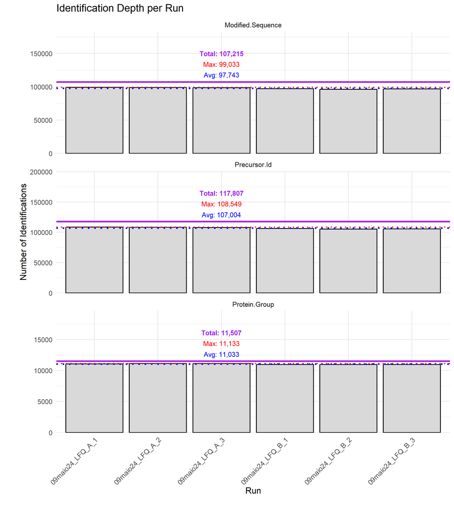

Identification Depth per Run

Precursors, peptides, and protein groups

| Run | Precursors | Peptides | Protein.Groups |
| --- | --- | --- | --- |
| 09maio24_LFQ_A_1 | 108,549 | 99,033 | 11,061 |
| 09maio24_LFQ_A_2 | 108,186 | 98,781 | 11,133 |
| 09maio24_LFQ_A_3 | 108,080 | 98,647 | 11,121 |
| 09maio24_LFQ_B_1 | 106,334 | 97,135 | 10,973 |
| 09maio24_LFQ_B_2 | 105,204 | 96,185 | 10,966 |
| 09maio24_LFQ_B_3 | 105,673 | 96,679 | 10,946 |

TOTAL across all runs - Peptides: 107,215; Precursors: 117,807; Protein Groups: 11,507

# 2. Quantitative signal composition

**NoteRelative abundance and contaminant contribution**

This section summarizes the **relative distribution of protein‑level signal across runs**, including the fraction attributed to protein groups annotated as contaminants.

Relative abundance profiles provide a concise assessment of sample composition and quantitative balance between runs. Consistent patterns indicate stable sample preparation and instrument response, whereas pronounced shifts may reflect differences in sample loading, background contamination, or overall signal balance.

Contaminant-specific plots highlight signal originating from common background proteins (e.g. keratins, proteolytic enzymes, laboratory contaminants). Elevated or variable contaminant contributions can affect identification depth and quantitative robustness.

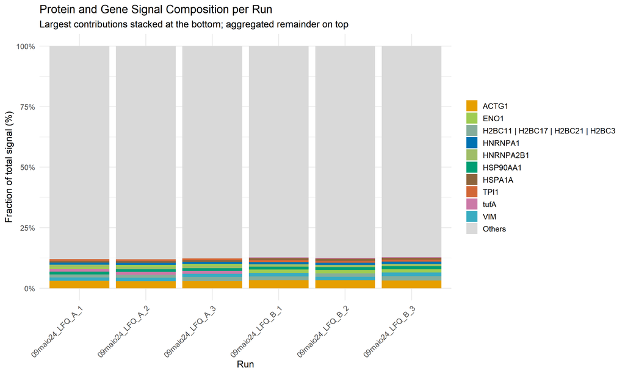

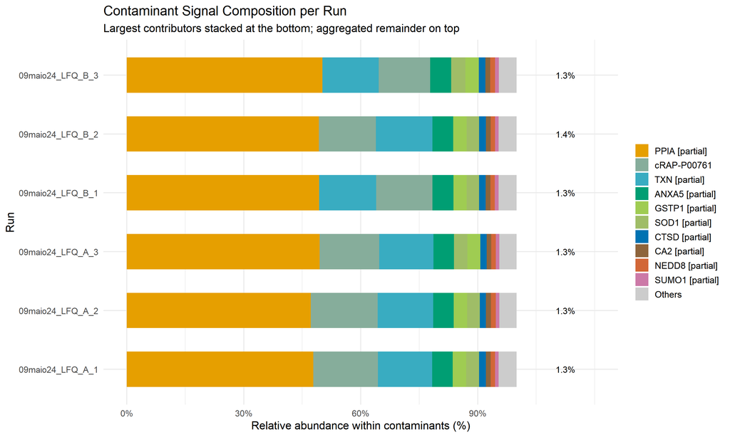

# 3. Sequence coverage

**NoteProtein sequence coverage**

This section summarizes **protein sequence coverage** based on the mapping of identified peptides to reference protein sequences.

Coverage reflects the fraction of amino acid positions supported by at least one peptide. The summary table reports the **top 100 proteins** ranked by sequence coverage, while the density plot provides a global overview of coverage distribution across the proteome.

The complete coverage table, including peptide evidence for all proteins, is exported as a CSV file for reference and downstream inspection. Sequence coverage complements identification depth by describing how extensively individual protein sequences are sampled rather than how many proteins are detected.

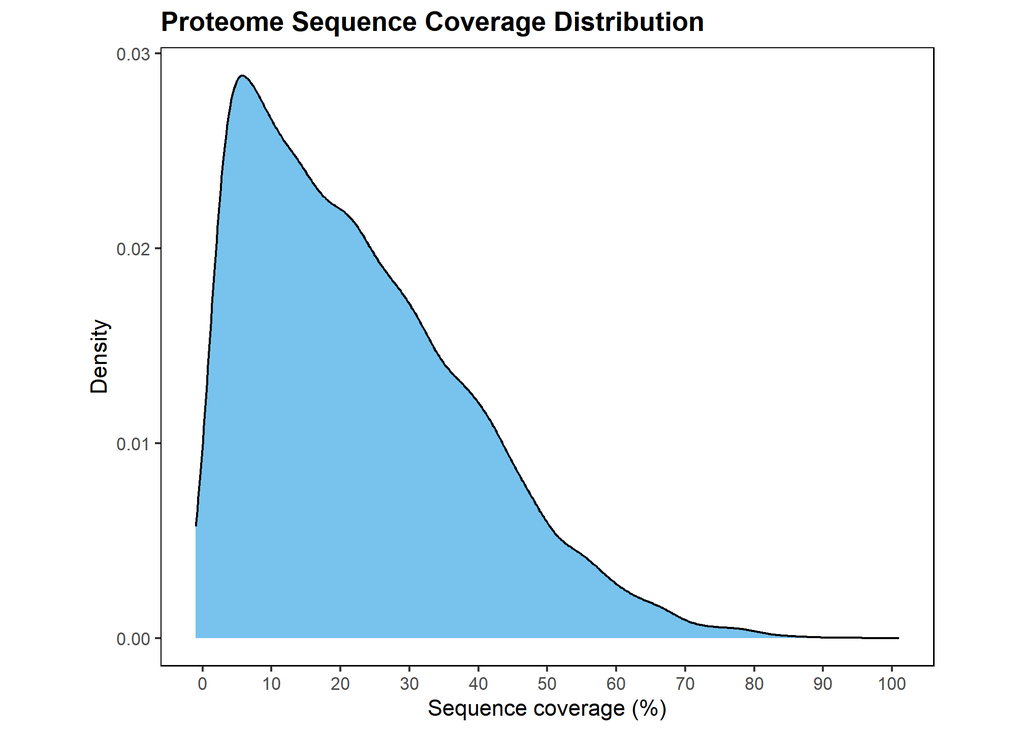

Protein Sequence Coverage Summary (Top 100)

Full peptide evidence is exported as CSV

| Accession | Protein Name | Length (aa) | Covered AA | Coverage (%) |
| --- | --- | --- | --- | --- |
| P0AB61 | Protein YciN | 83 | 74 | 89.2% |
| P60174 | Triosephosphate isomerase | 249 | 215 | 86.3% |
| P04075 | Fructose-bisphosphate aldolase A | 364 | 311 | 85.4% |
| O75368 | Adapter SH3BGRL | 114 | 97 | 85.1% |
| P10599 | Thioredoxin | 105 | 89 | 84.8% |
| P00445 | Superoxide dismutase [Cu-Zn] | 154 | 127 | 82.5% |
| Q9Y333 | U6 snRNA-associated Sm-like protein LSm2 | 95 | 78 | 82.1% |
| P68066 | Autonomous glycyl radical cofactor | 127 | 104 | 81.9% |
| P41227 | N-alpha-acetyltransferase 10 | 235 | 192 | 81.7% |
| O95777 | U6 snRNA-associated Sm-like protein LSm8 | 96 | 78 | 81.2% |
| P21796 | Non-selective voltage-gated ion channel VDAC1 | 283 | 228 | 80.6% |
| O43715 | TP53-regulated inhibitor of apoptosis 1 | 76 | 61 | 80.3% |
| P0AF36 | Cell division protein ZapB | 81 | 65 | 80.2% |
| P04080 | Cystatin-B | 98 | 78 | 79.6% |
| P0AC62 | Glutaredoxin 3 | 83 | 66 | 79.5% |
| Q9BSY4 | Coiled-coil-helix-coiled-coil-helix domain-containing protein 5 | 110 | 87 | 79.1% |
| P0ACD4 | Iron-sulfur cluster assembly scaffold protein IscU | 128 | 101 | 78.9% |
| P22943 | 12 kDa heat shock protein | 109 | 86 | 78.9% |
| P08758 | Annexin A5 | 320 | 252 | 78.8% |
| P68919 | Large ribosomal subunit protein bL25 | 94 | 74 | 78.7% |
| Q96EL3 | Large ribosomal subunit protein mL53 | 112 | 88 | 78.6% |
| P40037 | Protein HMF1 | 129 | 101 | 78.3% |
| P0A972 | Cold shock-like protein CspE | 69 | 54 | 78.3% |
| Q02790 | Peptidyl-prolyl cis-trans isomerase FKBP4 | 459 | 359 | 78.2% |
| P80723 | Brain acid soluble protein 1 | 227 | 177 | 78% |
| P56277 | Cx9C motif-containing protein 4 | 68 | 53 | 77.9% |
| P19623 | Spermidine synthase | 302 | 235 | 77.8% |
| Q99497 | Parkinson disease protein 7 | 189 | 147 | 77.8% |
| Q9H2H8 | Peptidyl-prolyl cis-trans isomerase-like 3 | 161 | 125 | 77.6% |
| P62888 | Large ribosomal subunit protein eL30 | 115 | 89 | 77.4% |

[output cut: 70 more lines]

# 4. Peptide-level quality

**NotePeptide‑level metrics**

This section summarizes **peptide‑level quality metrics** derived from identified peptides, including precursor **charge‑state distribution**, **peptide length**, and **missed tryptic cleavages**.

Charge‑state distributions reflect precursor ionization behavior and chemistry, while peptide length distributions summarize digestion outcome and peptide detectability. Digestion efficiency is assessed through the fraction of peptides containing at least one missed tryptic cleavage.

Together, these metrics provide complementary information to identification counts by capturing changes in peptide chemistry and digestion performance that may not be evident at the protein level.

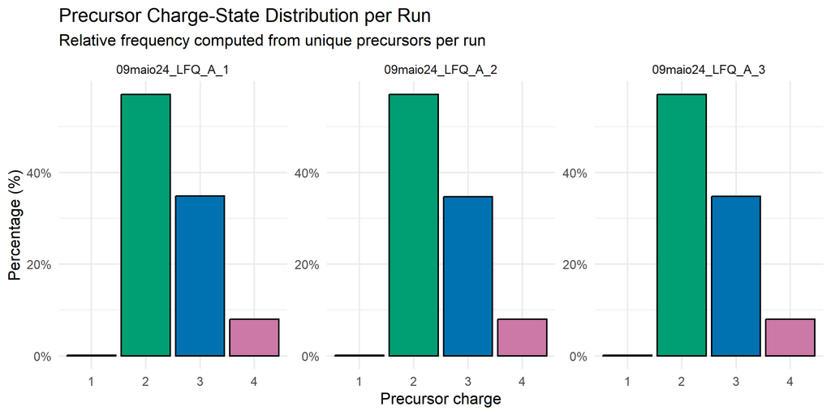

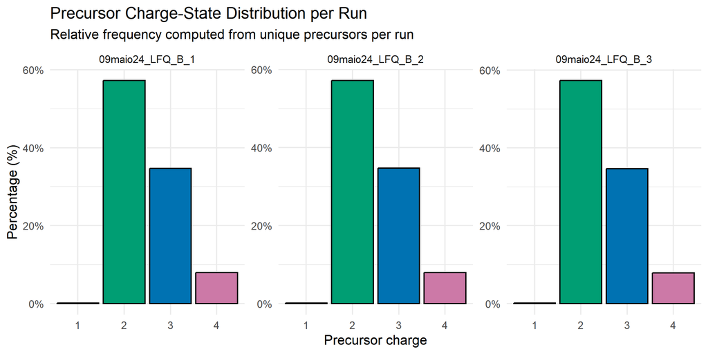

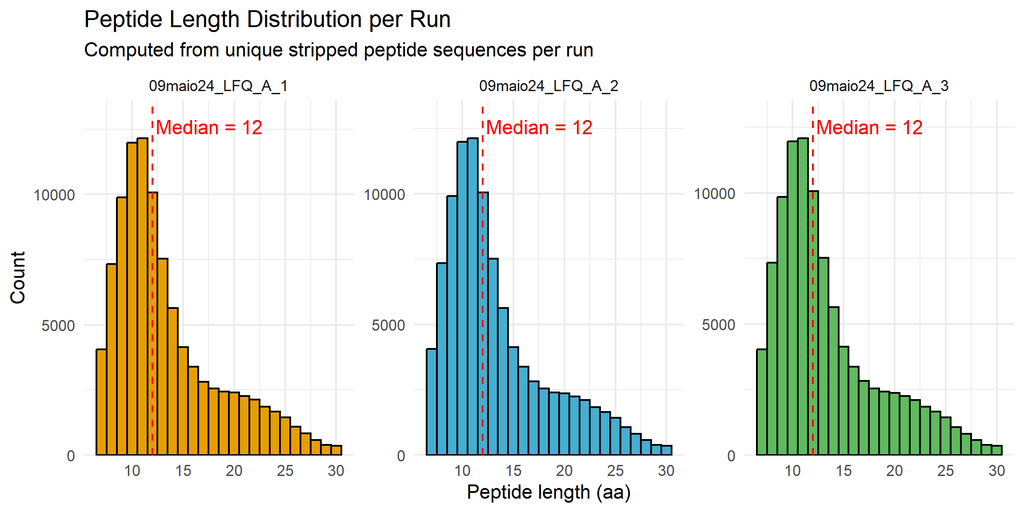

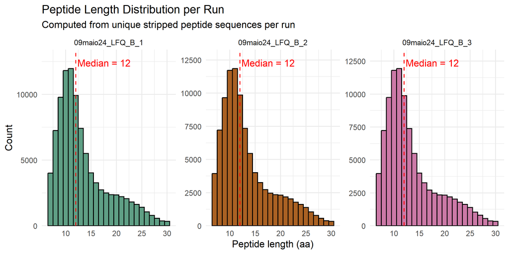

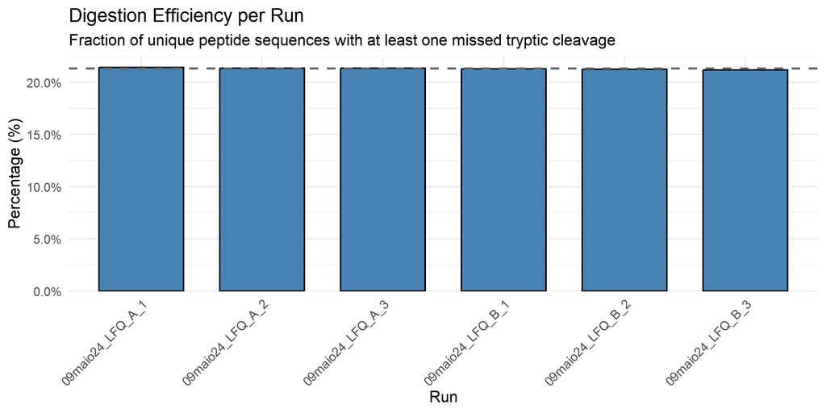

# 5. Chromatographic performance

**NoteChromatography quality**

This section evaluates **chromatographic performance and retention‑time behavior** across runs using peptide identification density, peak width metrics, and internal standard monitoring.

Identification density over retention time summarizes how peptide identifications are distributed across the LC gradient, providing an overview of gradient utilization and stability. Peak width metrics, including **full width at half maximum (FWHM)** and **peak base width**, characterize chromatographic peak shape and separation efficiency.

Retention‑time reproducibility and quantitative stability of **trypsin autolysis peptides** are assessed as internal standards, providing an instrument‑ and workflow‑level reference independent of biological variation. Together, these plots highlight changes in chromatographic performance such as gradient drift, peak broadening, or reduced run‑to‑run stability.

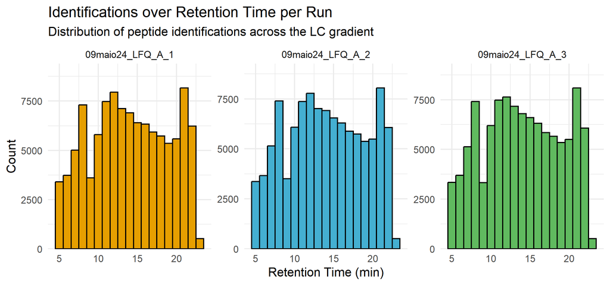

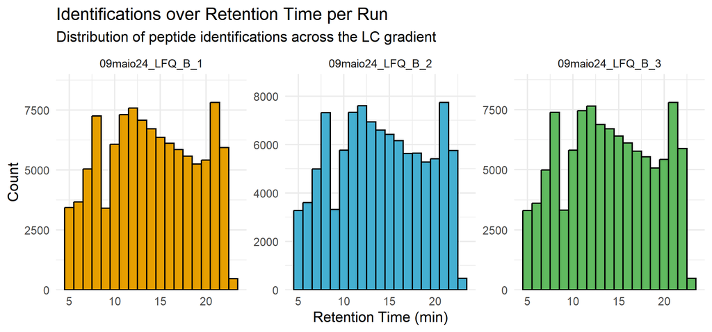

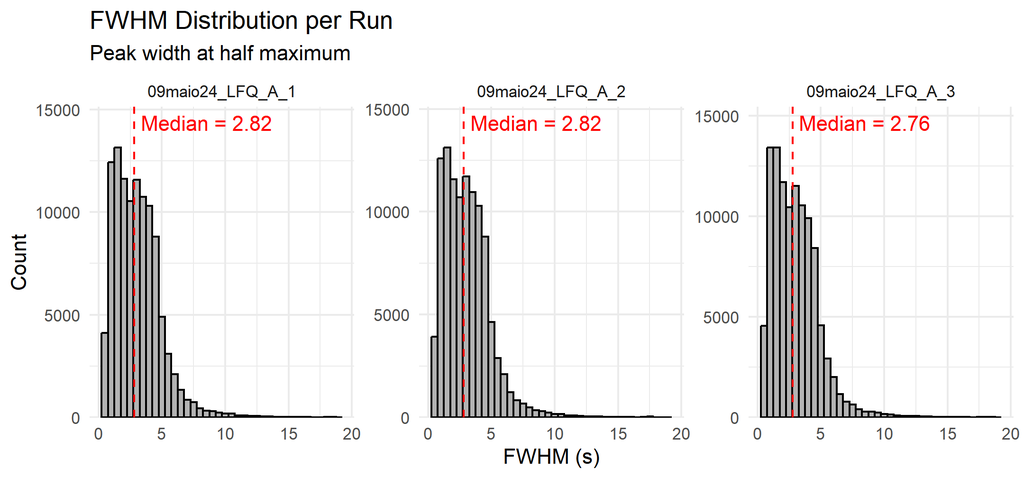

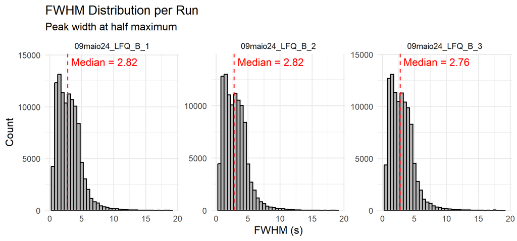

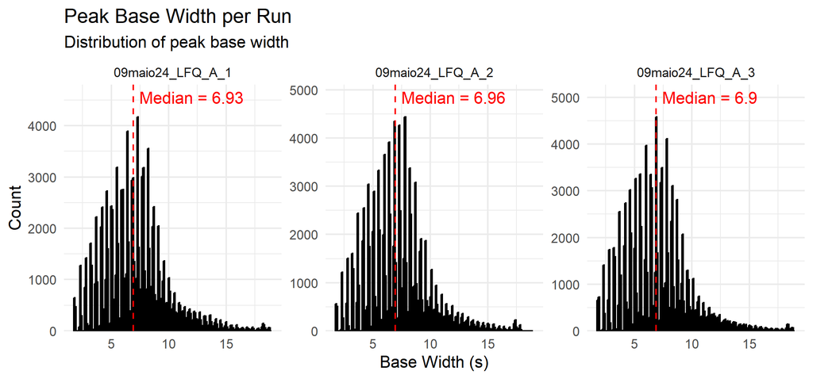

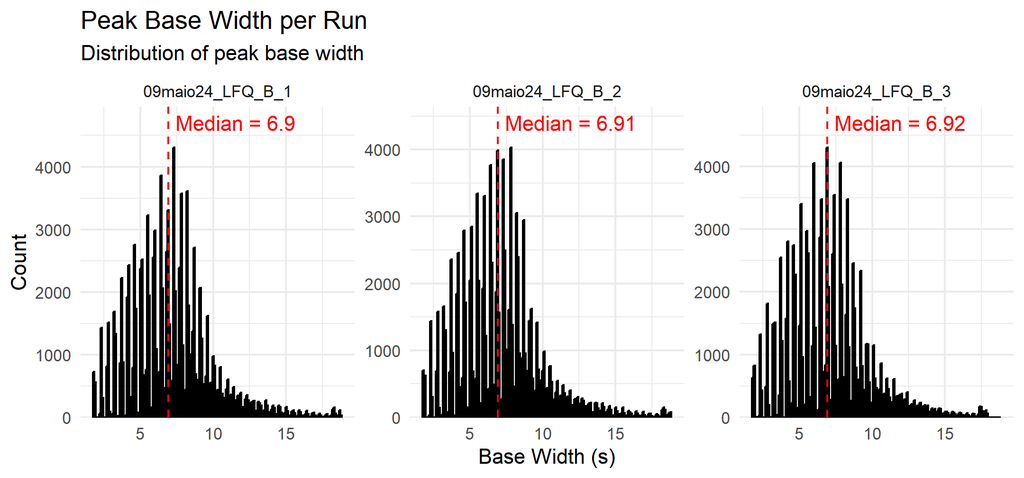

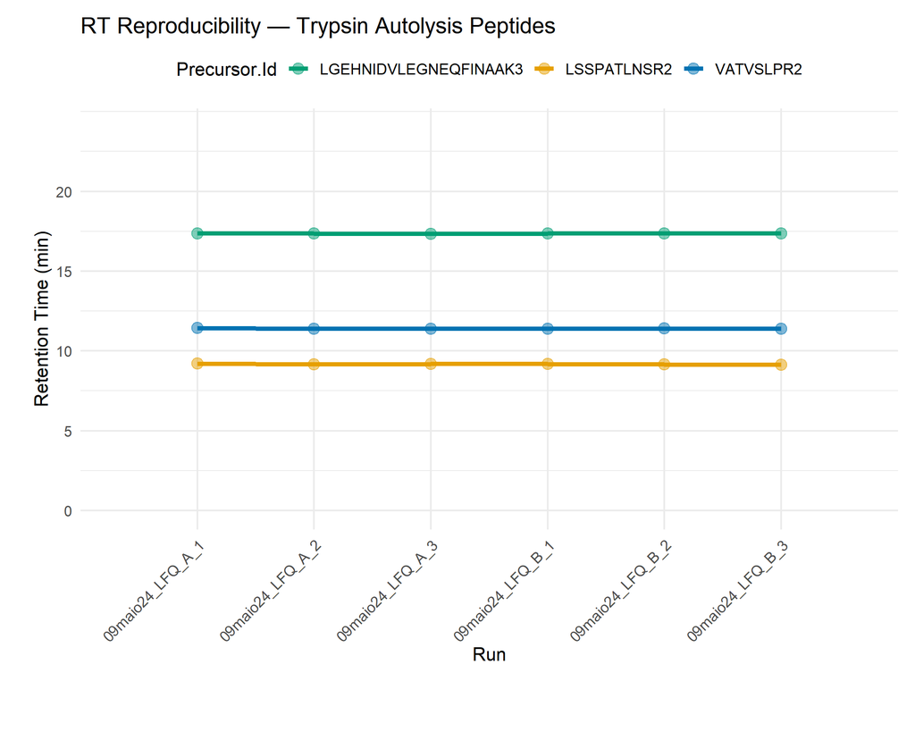

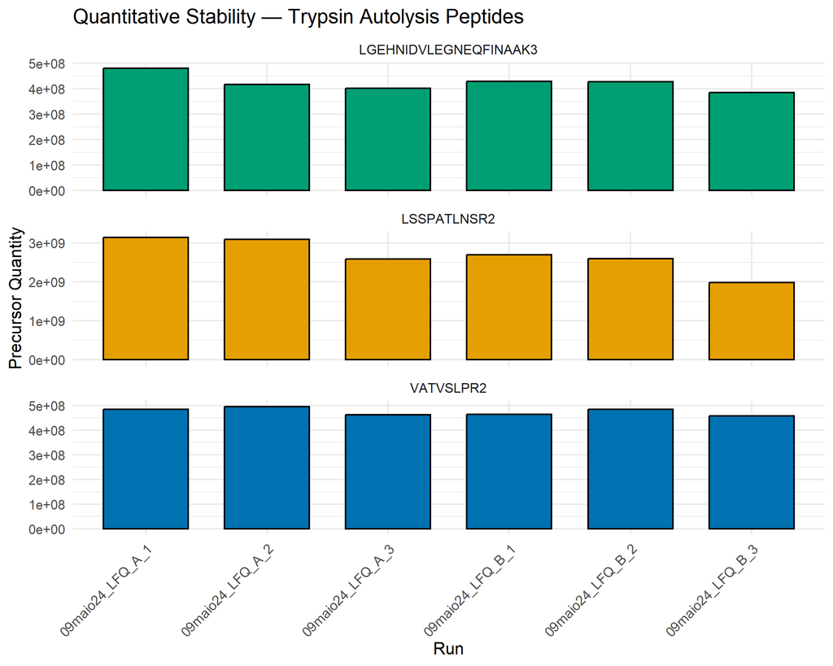

# 6. Mass accuracy

**NoteMass accuracy**

This section summarizes **precursor mass measurement error (m/z delta)** across runs to assess systematic bias and stability over the m/z range.

Stable mass accuracy is characterized by median deviations consistently centered around zero across the m/z range. Systematic trends (e.g., increasing or decreasing bias with m/z) indicate potential calibration issues or mass‑dependent inaccuracies, while increased spread or irregular profiles suggest reduced measurement stability.

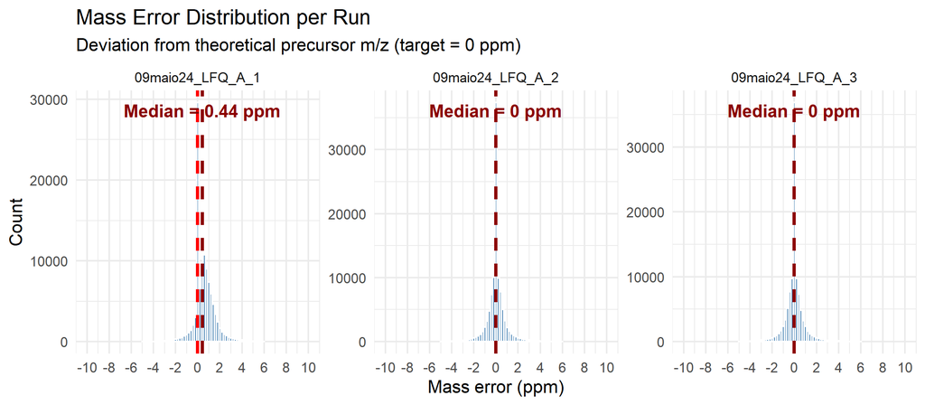

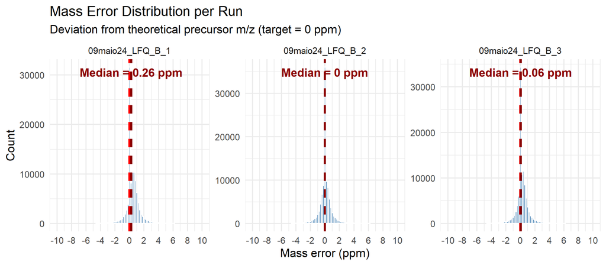

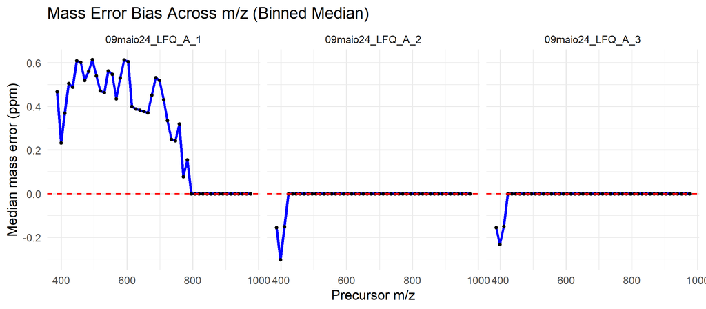

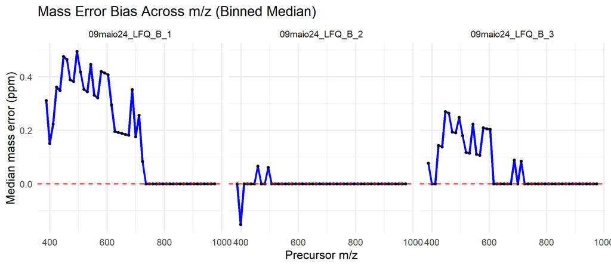

# 7. Quantification quality

**NoteDIA-NN quantification quality**

This section summarizes DIA‑NN quantification quality metrics at the precursor and protein‑group levels, providing an integrated view of signal reliability and consistency across runs.

**Quantity.Quality** reflects precursor‑level signal cleanness and sensitivity to interference, with higher values indicating more reliable extraction.  
**Empirical.Quality** captures cross‑run consistency of precursor behavior, summarizing agreement in quantitative features across the experiment.  
**PG.MaxLFQ.Quality** reflects the stability of protein‑group quantification after MaxLFQ aggregation.

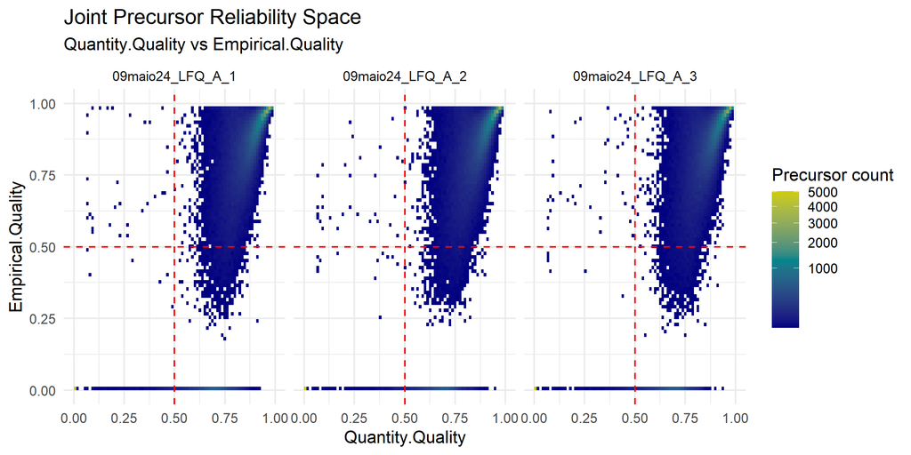

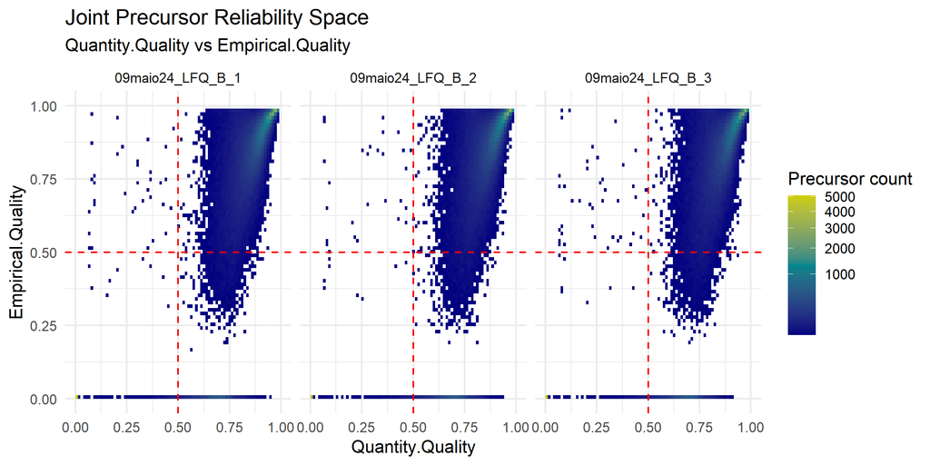

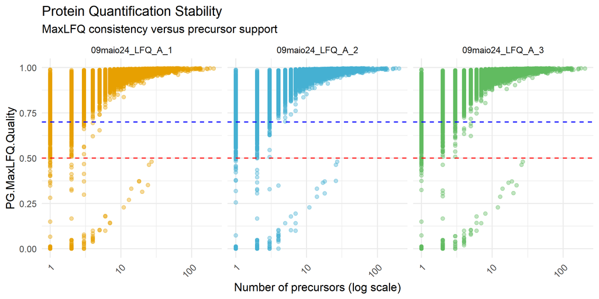

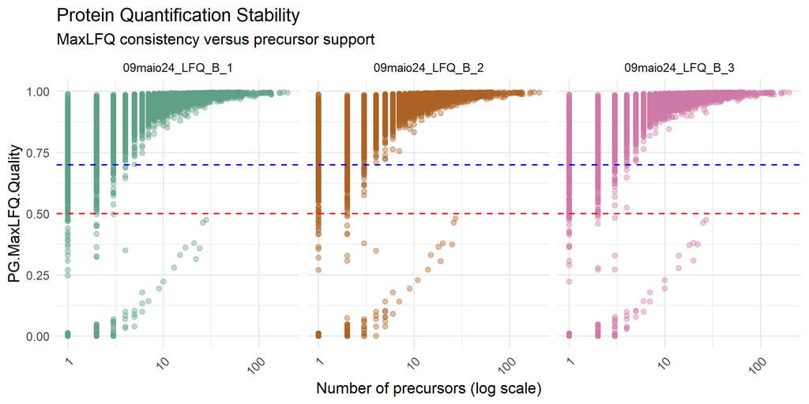

# 8. Intensity and LFQ distribution

**NoteIntensity and LFQ distribution**

This section summarizes **quantitative signal intensity distributions** at both the **precursor level (raw signal)** and the **protein level after LFQ normalization**.

Density plots depict the distribution of raw precursor intensities across runs, providing an overview of signal range and abundance prior to protein-level aggregation. Boxplots summarize LFQ‑normalized protein intensities, highlighting the spread and consistency of quantitative signal across runs.

Stable intensity profiles indicate consistent instrument response and effective normalization, whereas pronounced shifts or increased dispersion may reflect differences in signal loading or normalization performance.

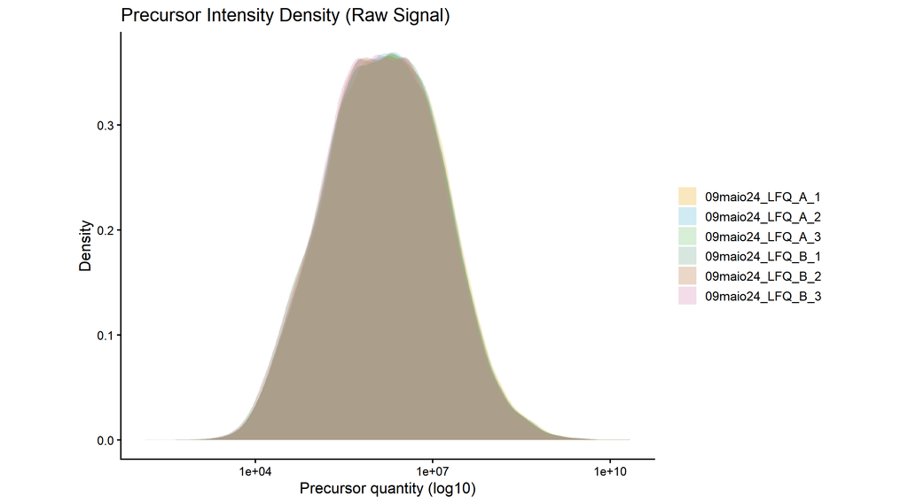

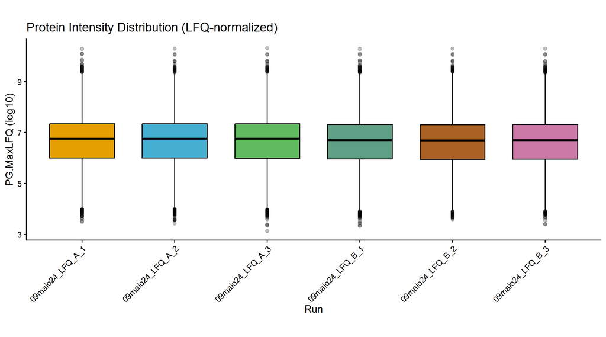

# 9. Data completeness

**NoteData completeness**

This section reports **precursor‑level data completeness**, defined as the presence or absence of quantitative signal in the run × precursor matrix.

Global completeness summarizes the fraction of all possible run–precursor values that are observed across the dataset, while run‑level completeness metrics describe the proportion of precursors detected in each individual run.

These summaries characterize the consistency of precursor detection across runs and provide context for downstream quantitative analyses by highlighting missing values at the precursor level.

Precursor-level data completeness (global)

Computed across all runs and precursors

| Metric | Value |
| --- | --- |
| Number of runs | 6 |
| Number of precursors | 117,807 |
| Total possible values (Run × Precursor) | 706,842 |
| Observed values | 642,026 |
| Data completeness (%) | 90.8 |

Run-level precursor completeness

Percentage of precursors detected per run

| Run | Observed | Total | Completeness_Pct |
| --- | --- | --- | --- |
| 09maio24_LFQ_A_1 | 108,549 | 117,807 | 92.1 |
| 09maio24_LFQ_A_2 | 108,186 | 117,807 | 91.8 |
| 09maio24_LFQ_A_3 | 108,080 | 117,807 | 91.7 |
| 09maio24_LFQ_B_1 | 106,334 | 117,807 | 90.3 |
| 09maio24_LFQ_B_2 | 105,204 | 117,807 | 89.3 |
| 09maio24_LFQ_B_3 | 105,673 | 117,807 | 89.7 |

# 10. Figures of Merit

**NoteFigures of Merit**

This section summarizes key run-level quality control metrics in a single table, providing an integrated overview of identification depth, chromatographic performance, retention-time reproducibility, mass accuracy, peptide characteristics, and contaminant contribution.

The table is intended as a compact QC dashboard for run-to-run comparison and longitudinal instrument monitoring. A complete per-run summary is also exported as a CSV file in the Results directory for downstream tracking and trend analysis.

Run-level Figures of Merit

Complete table exported as CSV

[output not shown]

# Reproducibility and session information

Execution environment summary

| Item | Value |
| --- | --- |
| Report generated on | 2026-10-07 10:59:50 |
| R version | R version 4.6.1 (2026-06-24 ucrt) |
| Quarto version | Not detected |
| Number of loaded packages | 19 |

Loaded R packages and versions

| Package | Version |
| --- | --- |
| gtExtras | 0.6.2 |
| gt | 1.3.0 |
| knitr | 1.51 |
| microseq | 2.1.7 |
| rlang | 1.2.0 |
| RColorBrewer | 1.1-3 |
| scales | 1.4.0 |
| ggrepel | 0.9.8 |
| arrow | 24.0.0 |
| lubridate | 1.9.5 |
| forcats | 1.0.1 |
| stringr | 1.6.0 |
| dplyr | 1.2.1 |
| purrr | 1.2.2 |
| readr | 2.2.0 |
| tidyr | 1.3.2 |
| tibble | 3.3.1 |
| ggplot2 | 4.0.3 |
| tidyverse | 2.0.0 |